# Usage of libraries

# Data understanding and preprocessing

# Univariate and Bivariate

```python
class DataAnalysis:

    def __init__(self, data):
     self.data = data
    def show_info(self):
       return self.data.info()
    def show_description(self):
        return self.data.describe()

class UnivariateAnalysis(DataAnalysis):

 def analyze(self):
   return self.data[['Open', 'Close', 'Volume']].describe()

class BivariateAnalysis(DataAnalysis):


 def analyze(self):
   return self.data[['Open', 'Close']].corr()
```

# Step 3 & 4: Data Splitting + Model Training & Testing (SVM)

```python
import numpy as np

class SimpleSVM:
    def __init__(self, C=1.0, learning_rate=0.001, n_iters=1000):
        self.C = C
        self.lr = learning_rate
        self.n_iters = n_iters
        self.w = None
        self.b = None

    def split_data(self, X, y, test_size=0.2, random_state=42):
        """
        Simple train-test split without sklearn.
        """
        np.random.seed(random_state)
        indices = np.arange(X.shape[0])
        np.random.shuffle(indices)
        split = int(X.shape[0] * (1 - test_size))
        train_idx, test_idx = indices[:split], indices[split:]
        return X[train_idx], X[test_idx], y[train_idx], y[test_idx]

    def create_model(self, n_features):
        """Initialize weights and bias."""
        self.w = np.zeros(n_features)
        self.b = 0
        print("Model created with weights initialized to zero.")

    def train(self, X, y):
        """Train the model using gradient descent for hinge loss."""
        for _ in range(self.n_iters):
            for idx, x_i in enumerate(X):
                condition = y[idx] * (np.dot(x_i, self.w) - self.b) >= 1
                if condition:
                    self.w -= self.lr * (2 * self.w)
                else:
                    self.w -= self.lr * (2 * self.w - np.dot(x_i, y[idx]) * self.C)
                    self.b -= self.lr * y[idx]
        print("Training completed.")

    def test(self, X, y):
        """Evaluate model accuracy."""
        y_pred = np.sign(np.dot(X, self.w) - self.b)
        accuracy = np.mean(y_pred == y)
        print(f"Test Accuracy: {accuracy*100:.2f}%")

# ========== Usage ==========
# Step 1: Create dummy data
from sklearn.datasets import make_classification

X, y = make_classification(n_samples=500, n_features=10, n_classes=2)
y = np.where(y == 0, -1, 1)  # Convert labels to -1 and 1

# Step 2: Create and train the model
svm = SimpleSVM()
X_train, X_test, y_train, y_test = svm.split_data(X, y)
svm.create_model(X_train.shape[1])
svm.train(X_train, y_train)
svm.test(X_test, y_test)

# Step 3 (Optional): Save the trained model
import pickle

with open('simple_svm_model.pkl', 'wb') as file:
    pickle.dump(svm, file)
print("Model saved successfully.")
```

```
Model created with weights initialized to zero.
Training completed.
Test Accuracy: 89.00%
Model saved successfully.
```

# Modal training using pickel

```python
import pickle
X, y = make_classification(n_samples=100, n_features=5)
model = SVC(probability=True)
model.fit(X, y)


model_filename = 'svm_model_largest_companies.pkl'
with open(model_filename, 'wb') as file:
    pickle.dump(model, file)

print(f"Model saved successfully as '{model_filename}'")
```

```
Model saved successfully as 'svm_model_largest_companies.pkl'
```

## Visualization

This class helps create basic visualizations to understand your dataset quickly.

### Methods:

- **`plot_histograms(numeric_cols)`**  
  Plots histograms for numeric columns to show their distributions.
- **`plot_correlation_heatmap()`**  
  Shows a heatmap of correlations between numeric features.
- **`plot_scatter(x_col, y_col, hue_col=None)`**  
  Creates a scatter plot between two variables, optionally colored by a category.

# VISUALIZTION OF BIVARIANT

## `Heatmap`

The purpose of a heatmap in data science — especially a correlation heatmap — is to visually represent the relationship between variables in a dataset.

### Heatmap (specifically correlation heatmap):

**Purpose:**

- To show how strongly each pair of features (columns) are related to each other.
- To help identify patterns, trends, or potential multicollinearity in your data.

**Why it's useful:**

- Spot redundant features (e.g., if two features are >0.9 correlated, maybe drop one).
- Select important features for models.
- Understand the structure of your data before training models.

## `Scatter plot`

A scatter plot shows the relationship between two numeric features, helping visualize trends, patterns, and potential outliers.

**Purpose of a Scatter Plot:**

- To visualize relationships, trends, or patterns between two variables.
- To spot correlations (positive, negative, or none).

To detect:

- Outliers
- Clusters
- Linear/non-linear trends

[figure not shown]

[figure not shown]

```python
def plot_correlation_heatmap(self):
        corr = self.df.corr(numeric_only=True)
        cmap = sns.diverging_palette(220, 20, as_cmap=True)
        plt.figure(figsize=(12, 5))  # shorter height
        sns.heatmap(
            corr,
            annot=True,
            fmt='.2f',
            cmap=cmap,
            linewidths=0.5,
            linecolor='white',
            square=True,
            cbar_kws={'shrink': 0.8}
        )
        plt.title('Correlation Heatmap', fontsize=16)
        plt.xticks(rotation=45)
        plt.yticks(rotation=0)
        plt.tight_layout()
        plt.show()

def plot_scatter(self, x_col, y_col, hue_col=None):
        plt.figure(figsize=(8, 4))  # shorter height
        sns.scatterplot(
            data=self.df,
            x=x_col,
            y=y_col,
            hue=hue_col,
            palette='viridis',
            s=60,
            edgecolor='black'
        )
        plt.title(f'Scatter Plot: {x_col} vs {y_col}', fontsize=14)
        plt.xlabel(x_col)
        plt.ylabel(y_col)
        plt.grid(True, linestyle='--', alpha=0.5)
        plt.tight_layout()
        plt.show()
        data = {
    'A': [1, 2, 3, 4, 5, 6],
    'B': [5, 3, 6, 9, 2, 7],
    'C': [10, 15, 10, 20, 25, 30],
    'Category': ['X', 'Y', 'X', 'Y', 'X', 'Y']
}
df = pd.DataFrame(data)

visualizer = DataVisualizer(df)
visualizer.plot_correlation_heatmap()
visualizer.plot_scatter('A', 'B', 'Category')
```

# VISUALIZATION OF UNIVARIANT

## `Histogram`

A histogram is a type of graph that shows the distribution of a single numerical variable by dividing the data into intervals (called bins) and counting how many values fall into each bin.

**Purpose of a Histogram:**

- To visualize how data is spread (i.e., distribution).
- To detect:
- Skewness (left, right, or symmetric)
- Outliers
- Peaks (modes) — where data is concentrated
- Helps you understand the shape of the data: normal, skewed, bimodal, etc.

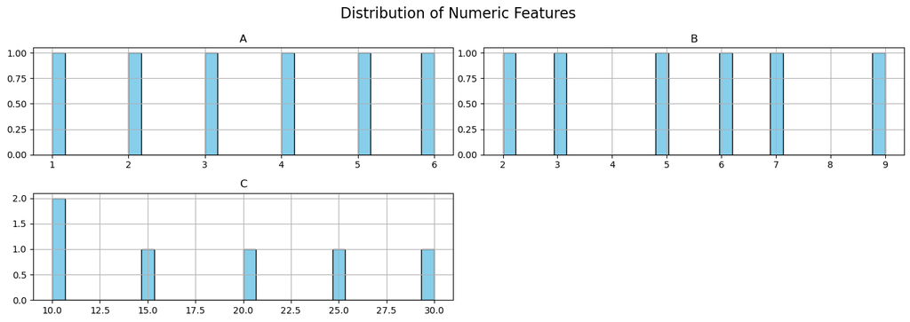

```python
import pandas as pd
import matplotlib.pyplot as plt

class DataVisualizer:
    def __init__(self, df):
        self.df = df

    def plot_histograms(self, numeric_cols):
        plt.figure(figsize=(14, 5))
        self.df[numeric_cols].hist(
            bins=30,
            figsize=(14, 5),
            color='skyblue',
            edgecolor='black'
        )
        plt.suptitle('Distribution of Numeric Features', fontsize=16)
        plt.tight_layout()
        plt.show()

# Sample Data
data = {
    'A': [1, 2, 3, 4, 5, 6],
    'B': [5, 3, 6, 9, 2, 7],
    'C': [10, 15, 10, 20, 25, 30],
    'Category': ['X', 'Y', 'X', 'Y', 'X', 'Y']
}
df = pd.DataFrame(data)

# Using the class
visualizer = DataVisualizer(df)
visualizer.plot_histograms(['A', 'B', 'C'])
```

## `Bar Chart`

A bar chart is used to compare different categories using rectangular bars. Each bar represents a category, and the length or height of the bar shows its value or frequency.

**Purpose of a Bar Chart:**

- To compare quantities across categories (e.g., sectors, countries, companies).
- Useful when dealing with categorical data.
- Highlights the largest, smallest, or most common categories.

[figure not shown]

```python
# Top 10 companies by Revenue
top_10 = df.sort_values(by='Revenue (USD millions)', ascending=False).head(10)

# Bar Chart
plt.figure(figsize=(10, 6))
sns.barplot(x='Revenue (USD millions)', y='Name', data=top_10, palette='viridis')
plt.title('Top 10 Companies by Revenue (USD millions)', fontsize=14)
plt.xlabel('Revenue (USD millions)', fontsize=12)
plt.ylabel('Company Name', fontsize=12)
plt.tight_layout()
plt.show()
```

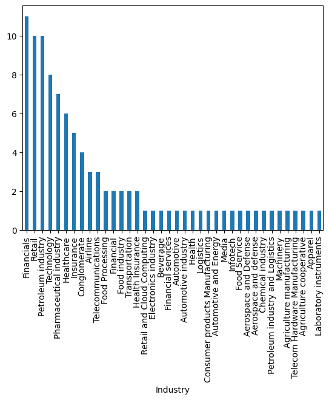

```python
df['Industry'].value_counts().plot(kind="bar")
```

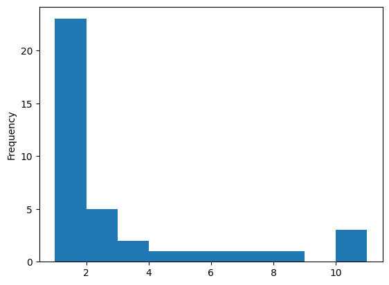

```python
df['Industry'].value_counts().plot(kind="hist")
```

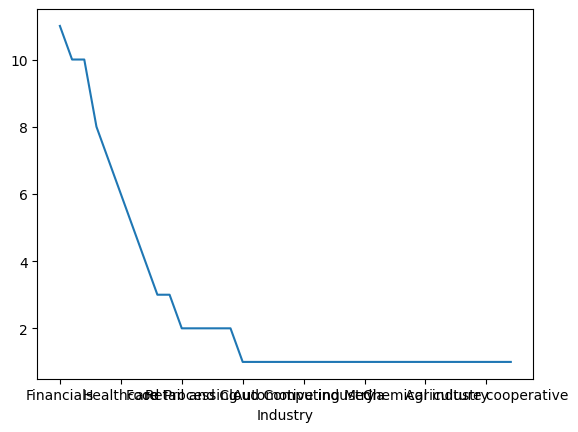

```python
df['Industry'].value_counts().plot(kind="line")
```

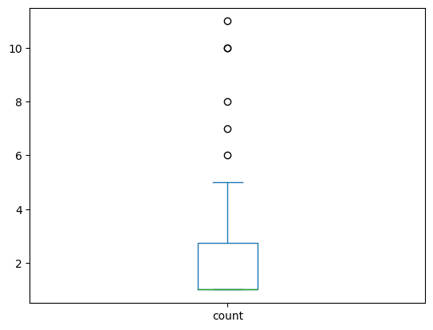

```python
df['Industry'].value_counts().plot(kind="box")
```

```python
visualizer = DataVisualizer('/mnt/data/Largest_Companies.csv')
```